# Laiko eilučių laboratorinių darbų užduotis

Įskaitinių eismo įvykių Lietuvoje analizė

Linas Šyvis ir Manvydas Sokolovas

- **1.Duomenų apžvalga**

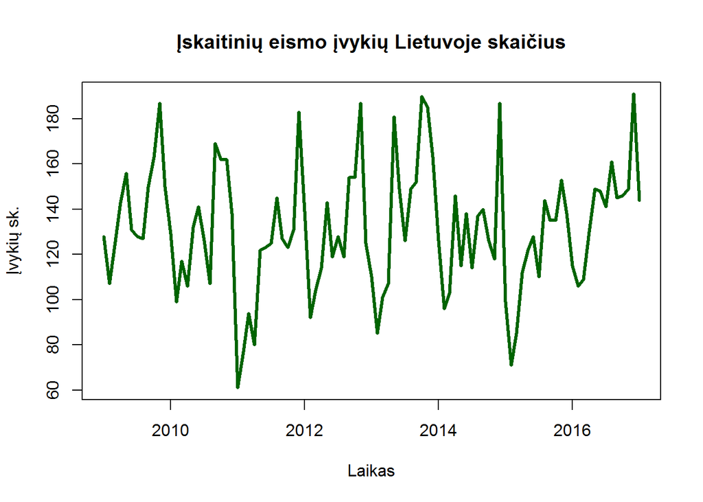

Nagrinėti 2009-2017 metų mėnesiniai įskaitinių eismo įvykių Lietuvoje duomenys. Šaltinis - Lietuvos statistikos departamentas. Duomenyse matomas sezoniškumas (įvykių skaičiaus sumažėjimas kiekvienų metų pradžioje ir padidėjimas pabaigoje). Aiškų trendą sunku įžvelgti.

- **2. Kiti rodikliai**

Sezoniškumo ir kitų nuokrypių pagrindinės priežastys tikėtinai yra metų laikas, kuro kainos, alkoholio vartojimas, gyventojų, emigrantų skaičius.

- **3.1.Sezoniškumo įvertinimas**

Duomenyse pastebimas akivaizdus sezoniškumas, todėl jam įvertinti naudosime $stl()$ funkciją, kuri iš laiko eilutės išskiria sezoninę ir trendo komponentes.

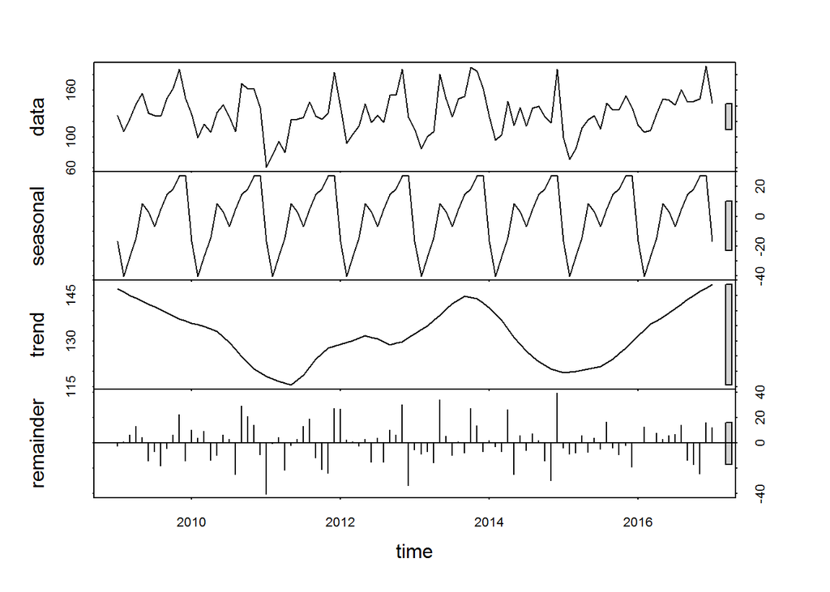

Grafikas patvirtina, kad duomenyse egzistuoja tam tikras sezoniškumas ir trendas ir juos išskiria.

- **3.2.Stacionarumo įvertinimas**

Augmented Dickey-Fuller testo $H_0$ hipotezė tikrina ar duomenys turi vienetinę šaknį:

```
##
##  Augmented Dickey-Fuller Test
##
## data:  nusez
## Dickey-Fuller = -3.0691, Lag order = 4, p-value = 0.1351
## alternative hypothesis: stationary
```

ADF testo $H_0$ hipotezės atmesti negalime, testo p reikšmė > 0.05. Taip gali būti dėl heteroskedastiškumo.

Phillips-Perron testo $H_0$ hipotezė tikrina, ar duomenys turi vienetinę šaknį, o Kwiatkowski-Phillips-Schmidt-Shin $H_0$ hipotezė tikrina, ar duomenys yra stacionarūs.

```
##
##  Phillips-Perron Unit Root Test
##
## data:  nusez
## Dickey-Fuller Z(alpha) = -72.745, Truncation lag parameter = 3,
## p-value = 0.01
## alternative hypothesis: stationary
```

```
##
##  KPSS Test for Level Stationarity
##
## data:  nusez
## KPSS Level = 0.1364, Truncation lag parameter = 2, p-value = 0.1
```

Testai sufleruoja, kad duomenys stacionarūs. Taigi duomenų transformacijų atlikti nebūtina.

- **4.1.Tiesinis modelis**

Tikrinant, ar modelis turi struktūrinių lūžių, panaudota $breakpoints$ funkcija iš {strucchange} paketo.

```
##
##   Optimal 1-segment partition:
##
## Call:
## breakpoints.formula(formula = ivykiu_skaicius ~ dyzelinas + pirma_karta_registruotos_priemones +
##     krituliai_mm + Sausisbalandis, data = mod.data)
##
## Breakpoints at observation number:
## NA
##
## Corresponding to breakdates:
## NA
```

Duomenyse nepastebėta jokių struktūrinių lūžių.

- **5.Tiesinio modelio liekanos**

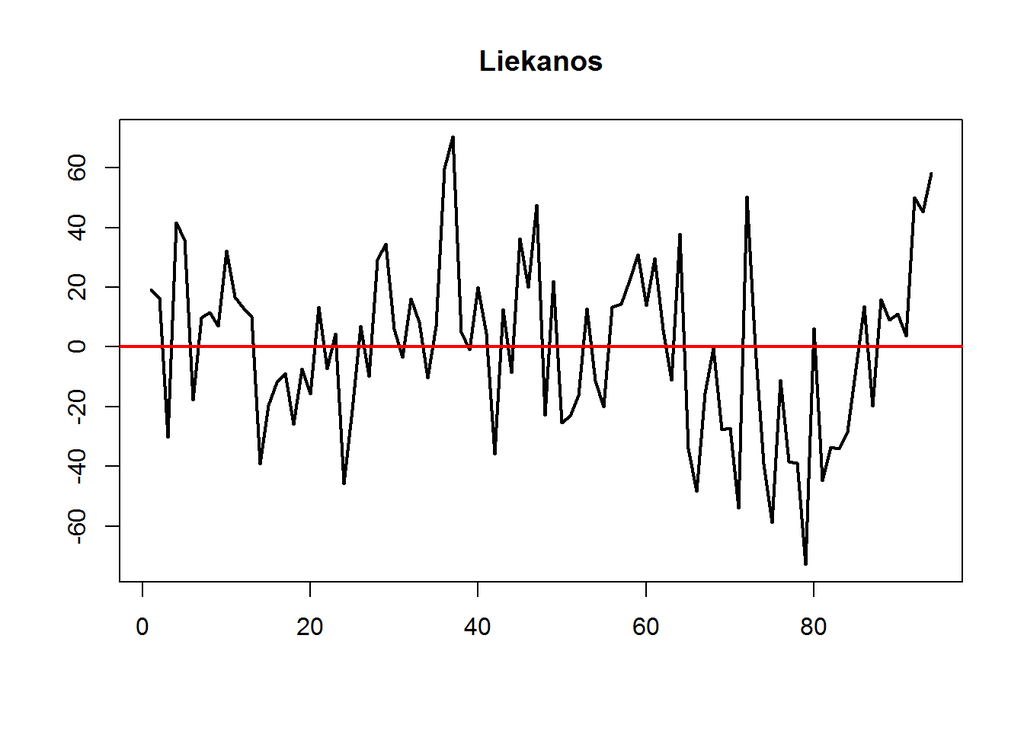

Duomenų liekanos daugmaž išsidėsčiusios apie 0 (raudona linija).

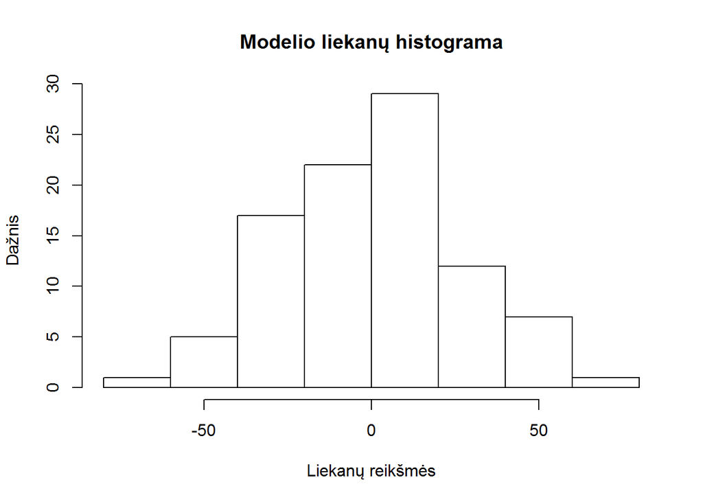

Iš histogramos pastebima, kad liekanų pasiskirstymas panašus į normalųjį.

Liekanas apžvelgsime ir ACF bei PACF grafikuose.

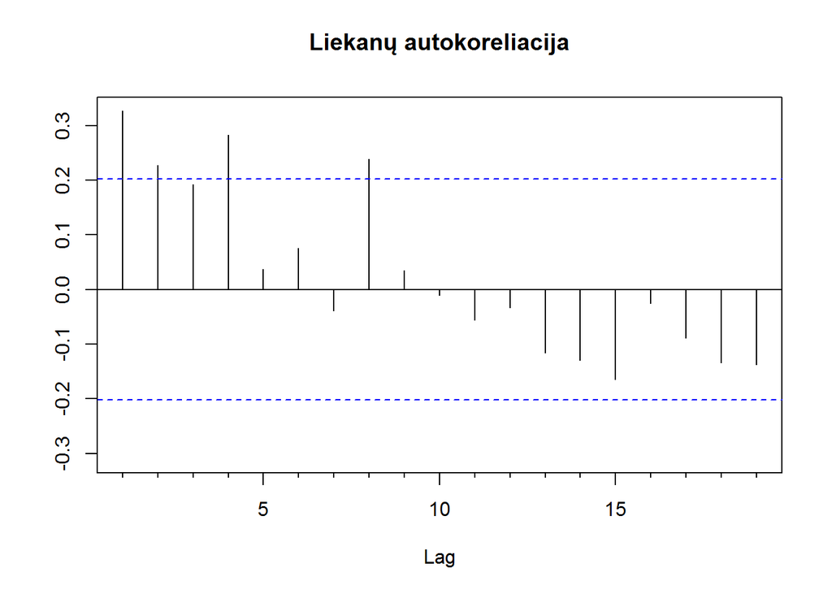

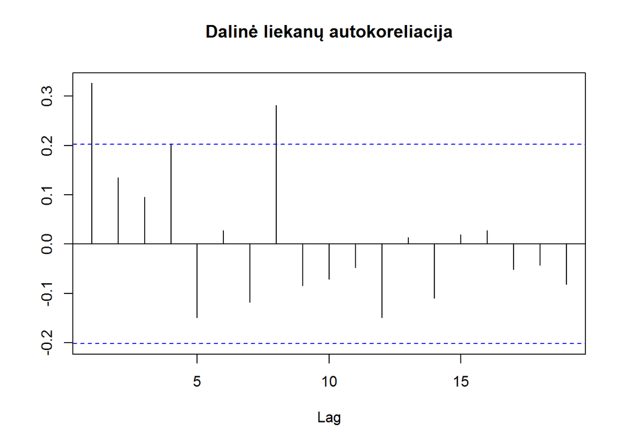

Grafikuose galima įžvelgti keletą reikšmingų vėlinių (išeina už mėlynos punktyrinės linijos). Todėl atliekamas Ljung-Box testas su $H_0$ hipoteze, kad liekanos yra baltasis triukšmas:

```
##
##  Box-Ljung test
##
## data:  tiesinis1$res
## X-squared = 10.321, df = 1, p-value = 0.001316
```

Gauta p reikšmė < 0.05. Liekanos nėra baltasis triukšmas. Todėl naudojama funkcija $auto.arima$ parinkti ARMA(p,q) modelį likučiams:

```
## Series: tiesinis1$res
## ARIMA(1,0,1) with zero mean
##
## Coefficients:
##          ar1      ma1
##       0.8177  -0.5605
## s.e.  0.1229   0.1675
##
## sigma^2 estimated as 699.6:  log likelihood=-440.37
## AIC=886.74   AICc=887   BIC=894.37
```

Gautas ARMA(1,1) modelis. Liekanas galima įvertinti modeliu ARMA(1,1)

```
##
##  Box-Ljung test
##
## data:  tiesinis2$res
## X-squared = 0.0094047, df = 1, p-value = 0.9227
```

Atlikus Ljung-Box testą, gauta p reikšmė > 0.05. Vadinasi negalima atmesti nulinės hipotezės bei teigti, kad pervertinto modelio liekanos nesudaro baltojo triukšmo.

- **6.1 Kryžminė patikra**

Modelio gerumas tikrinamas naudojant kryžminę patikrą. Algoritmo principas - kiekviename žingsnyje didinti prognozuojamos imties stebėjimų skaičių vienetu ir palyginti prognozes su tikromis reikšmėmis. Atlikus šį algoritmą prognozės tikslumas bus palygintas RMSE, MAE ir MAPE rodikliais.

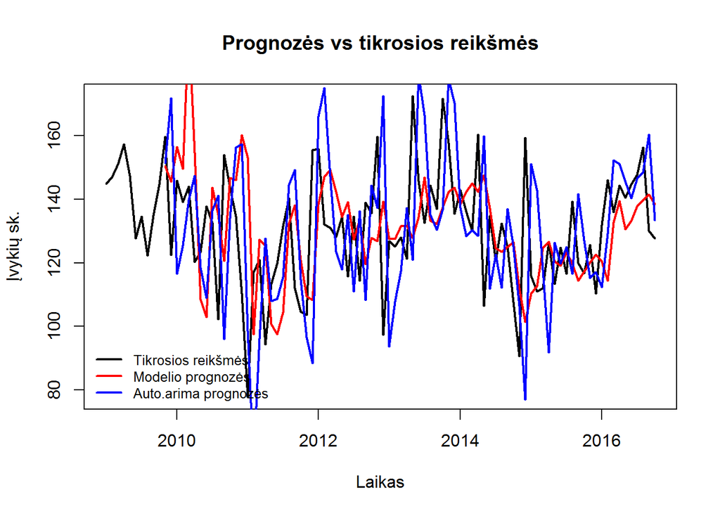

Iš grafiko sunku nustatyti, kurio modelio prognozės yra tikslesnės. Palyginsime gauto modelio prognozių ir $auto.arima$ modelio prognozių tikslumą pagal RMSE, MAE, MAPE.

```
##                RMSE      MAE     MAPE
## Modelis    22.25654 16.76242 13.48416
## Auto.arima 27.83897 21.73721 17.13000
```

Sprendžiant pagal RMSE, MAE ir MAPE, gauto modelio prognozės yra tikslesnės.